# HW2(2014_10451)

2014-10451

2020년 10월 25일

# Q1

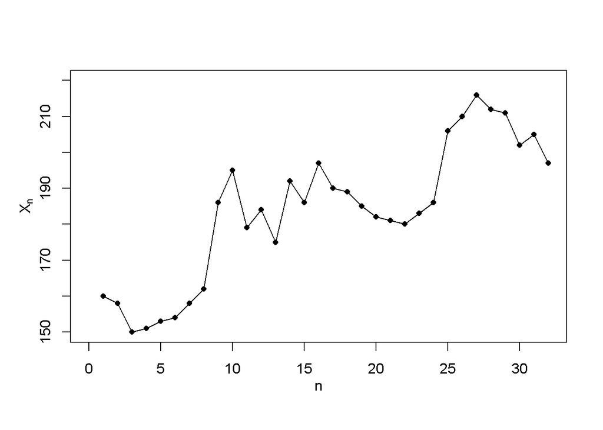

```r
tab_9e3 <- matrix(
  c(160,158,150,151,153,154,158,162,
    186,195,179,184,175,192,186,197,
    190,189,185,182,181,180,183,186,
    206,210,216,212,211,202,205,197),
    ncol=1,byrow=T)
x<-tab_9e3
t_vec<-1:length(x)
plot(t_vec,x,type="o",lty=1,pch=16,
     xlab="n",ylab=expression(X[n]),mgp=c(2,1,0),
     xlim=c(0,length(t_vec)),ylim=c(150,220),cex=0.8)
```

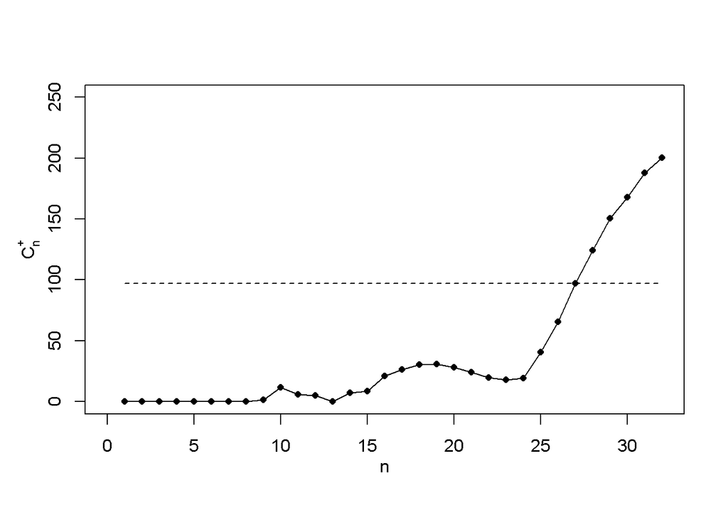

```r
k=0.5
h=5
sigma=sqrt(sum((x-mean(x))^2)/(length(x)-1))
K=k*sigma
H=h*sigma

cnx_p <- rep(0,length(x))
cnx_m <- rep(0,length(x))
mu0 <- 175
cnx_p[1]<-max(0,0+(x[1]-mu0-K))
cnx_m[1]<-max(0,mu0-K-x[1])

for(i in 2:length(x)){
  cnx_p[i]<-max(0,cnx_p[i-1]+x[i]-mu0-K)
  cnx_m[i]<-min(0,cnx_m[i-1]+mu0-x[i]-K)
}

#Upper CUSUM Statistic CUSUM Chart
plot(t_vec,cnx_p,type="o",lty=1,pch=16,
     xlab="n",ylab=expression(C[n]^{"+"}),mgp=c(2,1,0),
     xlim=c(0,length(t_vec)),
     ylim=c(0,250),cex=0.8)
lines(t_vec,rep(H,length(t_vec)),lty=2,cex=0.8)
```

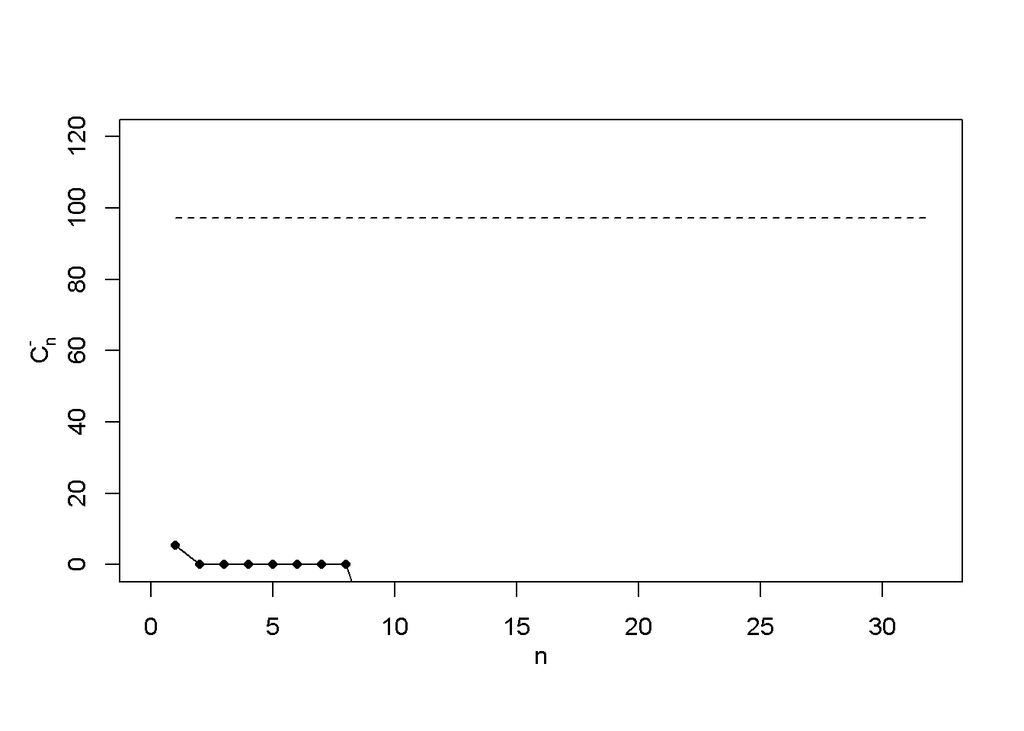

```r
#Lower CUSUM Statistic CUSUM Chart
plot(t_vec,cnx_m,type="o",lty=1,pch=16,
     xlab="n",ylab=expression(C[n]^{"-"}),mgp=c(2,1,0),
     xlim=c(0,length(t_vec)),
     ylim=c(0,120),cex=0.8)
lines(t_vec,rep(H,length(t_vec)),lty=2,cex=0.8)
```

(1)sigma의 추정량은 sample standard deviation으로 구할 수 있다. (19.43369) (2)H=h*sigma K=k*sigma를 구하고, 정해진 K를 이용해 Cn+,Cn- 통계량을 모두 구한 뒤 plotting하고 H line을 그린다.

# Q2

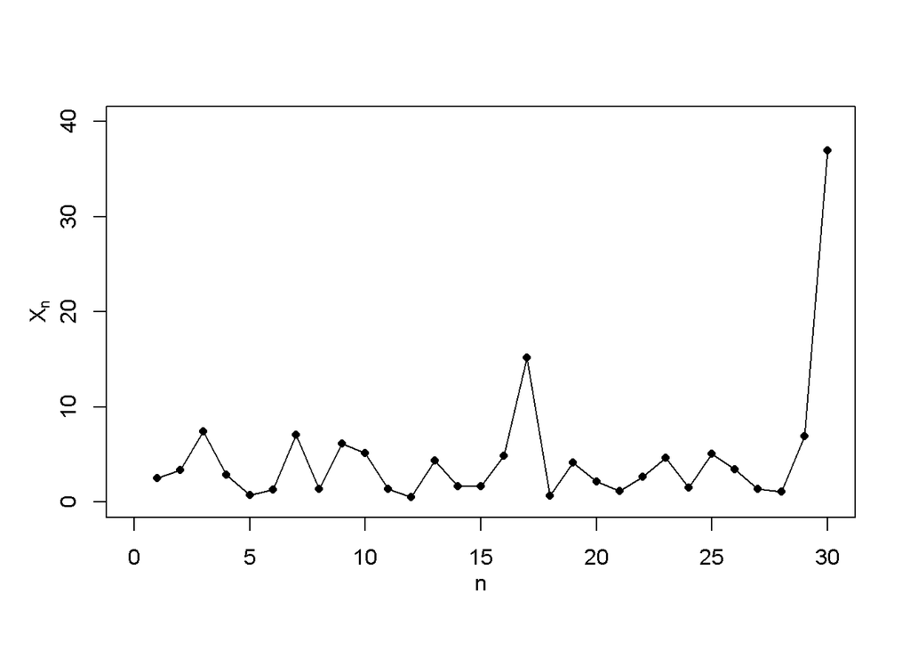

```r
tab_6e14 <- matrix(
  c(2.49,3.39,7.41,2.88,0.76,1.32,7.05,1.37,6.17,5.12,
    1.34,0.50,4.35,1.67,1.63,4.88,15.19,0.67,4.14,2.16,
    1.14,2.66,4.67,1.54,5.06,3.40,1.39,1.11,6.92,36.99),
    ncol=1,byrow=T)
x<-tab_6e14
t_vec<-1:length(x)
plot(t_vec,x,type="o",lty=1,pch=16,
     xlab="n",ylab=expression(X[n]),mgp=c(2,1,0),
     xlim=c(0,length(t_vec)),ylim=c(0,40),cex=0.8)
```

```r
mu0_hat<-mean(x)
sigma_hat<-sqrt(sum((x-mean(x))^2)/(length(x)-1))
mu0_hat
```

```
## [1] 4.645667
```

```r
sigma_hat
```

```
## [1] 6.807347
```

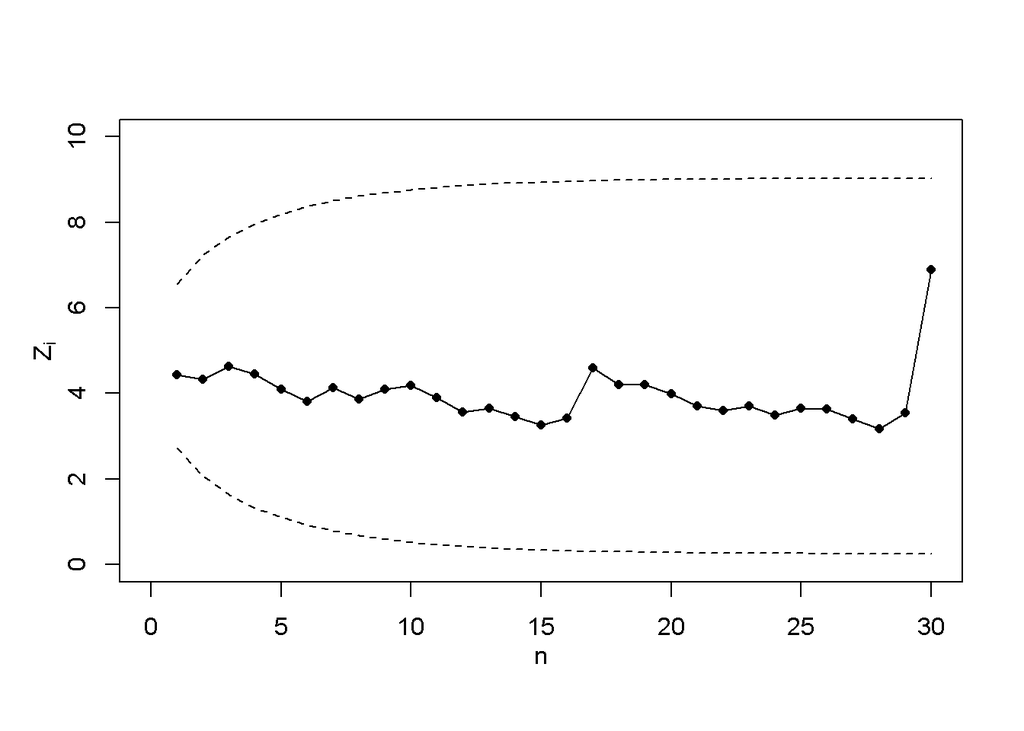

```r
lambda<-0.1
L<-2.814 #L=2.814, lambda=0.1 gives ARL0=500

#EWMA Statistic {Z_i} with Z_0=mu0_hat
Z<-rep(0,length(x))
UCL<-rep(0,length(x))
LCL<-rep(0,length(x))
UCL[1]<-mu0_hat+L*sigma_hat*sqrt(0.1*(1-0.9^2)/1.9)
LCL[1]<-mu0_hat-L*sigma_hat*sqrt(0.1*(1-0.9^2)/1.9)
Z[1]<-lambda*x[1]+(1-lambda)*mu0_hat

for(k in 2:length(x)){
  Z[k]<-lambda*x[k]+(1-lambda)*Z[k-1]
UCL[k]<-mu0_hat+L*sigma_hat*sqrt(0.1*(1-0.9^(2*k))/1.9)
LCL[k]<-mu0_hat-L*sigma_hat*sqrt(0.1*(1-0.9^(2*k))/1.9)
}

plot(t_vec,Z,type="o",lty=1,pch=16,
     xlab="n",ylab=expression(Z[i]),mgp=c(2,1,0),
     xlim=c(0,length(t_vec)),ylim=c(0,10),cex=0.8)
lines(t_vec,UCL,lty=2,cex=0.8)
lines(t_vec,LCL,lty=2,cex=0.8)
```

# Q3

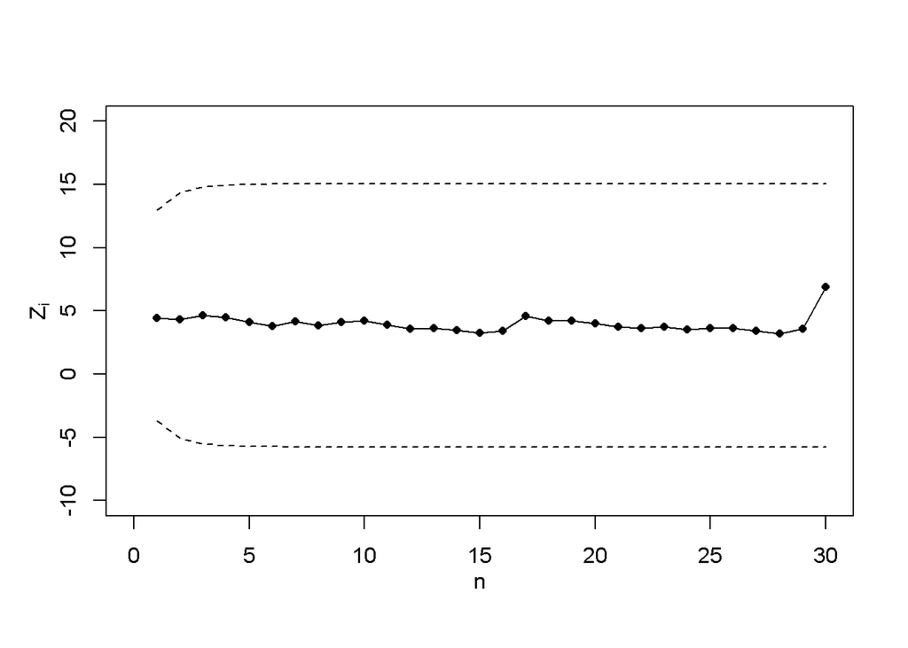

```r
lambda=0.4
L=3.054

for(k in 1:length(x)){
UCL[k]<-mu0_hat+L*sigma_hat*sqrt(0.4*(1-0.6^(2*k))/1.6)
LCL[k]<-mu0_hat-L*sigma_hat*sqrt(0.4*(1-0.6^(2*k))/1.6)
}

plot(t_vec,Z,type="o",lty=1,pch=16,
     xlab="n",ylab=expression(Z[i]),mgp=c(2,1,0),
     xlim=c(0,length(t_vec)),ylim=c(-10,20),cex=0.8)
lines(t_vec,UCL,lty=2,cex=0.8)
lines(t_vec,LCL,lty=2,cex=0.8)
```

앞선 문제와 동일하게 ARL0=500이라고 설정하자. lambda=0.4에서 ARL0=500을 주는 L=3.054이다(강의노트 Part II. Univariate Detection 5(EWMA) 11p.) 위 값을 적용하여 time-varying state에서 새로운 UCL,LCL 값들을 구하고 이를 다시 plotting하였다. 앞선 문제와 동일하게 모든 sample 특성치가 [LCL,UCL] 구간에 포함되어 있으며, 추가적으로 앞선 문제에 비해 [LCL,UCL]이 더 넓어진 것을 알 수 있다.

# Q4

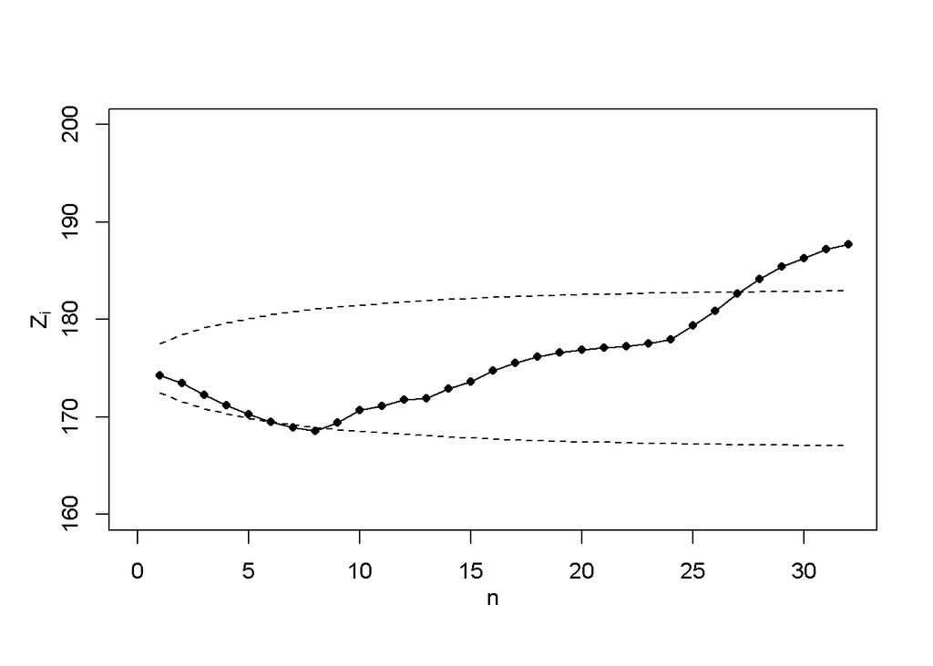

```r
x<-tab_9e3
mu0=175
sigma_hat=sqrt(sum((x-mean(x))^2)/(length(x)-1))
lambda=0.05
L=2.6
t_vec=1:length(x)

Z<-rep(0,length(x))
UCL<-rep(0,length(x))
LCL<-rep(0,length(x))
UCL[1]<-mu0+L*sigma_hat*sqrt(0.05*(1-0.95^2)/1.95)
LCL[1]<-mu0-L*sigma_hat*sqrt(0.05*(1-0.95^2)/1.95)
Z[1]<-lambda*x[1]+(1-lambda)*mu0

for(k in 2:length(x)){
  Z[k]<-lambda*x[k]+(1-lambda)*Z[k-1]
UCL[k]<-mu0+L*sigma_hat*sqrt(0.05*(1-0.95^(2*k))/1.95)
LCL[k]<-mu0-L*sigma_hat*sqrt(0.05*(1-0.95^(2*k))/1.95)
}

plot(t_vec,Z,type="o",lty=1,pch=16,
     xlab="n",ylab=expression(Z[i]),mgp=c(2,1,0),
     xlim=c(0,length(t_vec)),ylim=c(160,200),cex=0.8)
lines(t_vec,UCL,lty=2,cex=0.8)
lines(t_vec,LCL,lty=2,cex=0.8)
```

```r
which((LCL-Z)>0)
```

```
## [1] 6 7 8
```

앞선 문제와 마찬가지로 steady-state가 아닌 time-varying 가정으로 i차 항에 대한 LCL[i],UCL[i]를 모두 구하고 Z[i]가 그 구간에 포함되는지 확인해본 결과, i=6,7,8에서 Z가 LCL보다 작아 해당 구간에서 벗어난 것을 확인하였다. 따라서, 앞선 문제와 다르게 EWMA 특성치를 사용한 결과 해당 공정은 i=6에서 signal하여, O.C. 상태라는 결론을 얻는다.

# Q5

```r
table_4e8 <- matrix(c(
  81,56,82,
  112,73,66,
  108,62,76,
  95,61,66,
  111,68,78,
  98,65,71,
  98,64,84,
  115,72,61,
  112,72,77,
  103,63,74,
  117,72,59,
  103,71,85,
  100,65,64,
  105,64,71,
  100,71,85,
  115,66,65,
  113,84,78,
  107,71,76,
  117,74,90,
  96,68,81,
  107,60,72,
  90,57,89,
  119,69,61,
  85,59,77,
  107,70,83),
  nrow=25,ncol=3,byrow="T")
colnames(table_4e8) <- c("Systolic", "Diastolic","PulseRate")

x<-table_4e8[,3]
t_vec<-1:length(x)
mu0_hat<-mean(x)
sigma_hat<-sqrt(sum((x-mean(x))^2)/(length(x)-1))
lambda=0.2
L=2.962 #gives ARL0=500

Z<-rep(0,length(x))
UCL<-rep(0,length(x))
LCL<-rep(0,length(x))
UCL[1]<-mu0_hat+L*sigma_hat*sqrt(0.2*(1-0.8^2)/1.8)
LCL[1]<-mu0_hat-L*sigma_hat*sqrt(0.2*(1-0.8^2)/1.8)
Z[1]<-lambda*x[1]+(1-lambda)*mu0_hat

for(k in 2:length(x)){
  Z[k]<-lambda*x[k]+(1-lambda)*Z[k-1]
UCL[k]<-mu0_hat+L*sigma_hat*sqrt(0.2*(1-0.8^(2*k))/1.8)
LCL[k]<-mu0_hat-L*sigma_hat*sqrt(0.2*(1-0.8^(2*k))/1.8)
}
length(t_vec)
```

```
## [1] 25
```

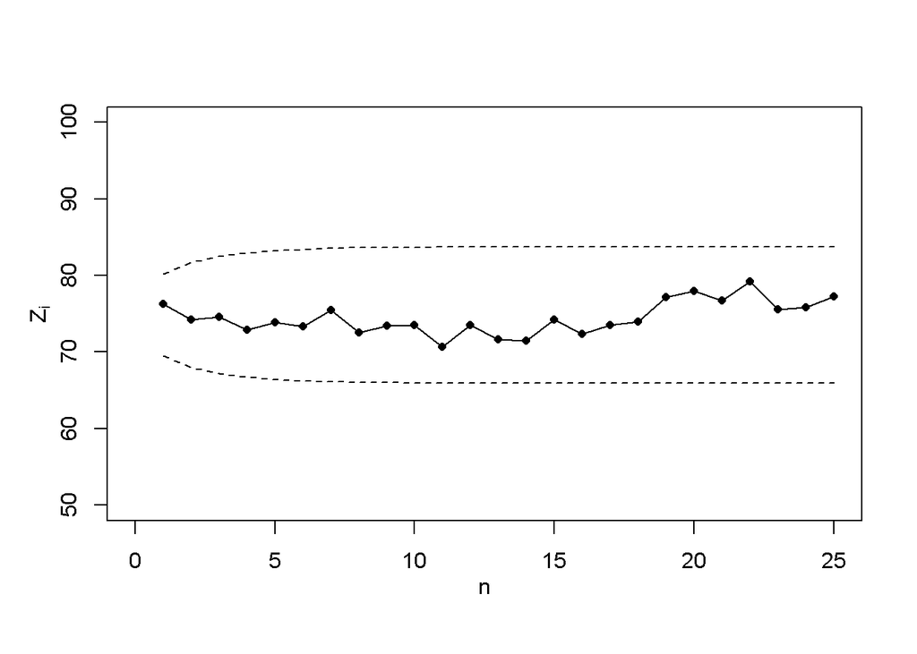

```r
plot(t_vec,Z,type="o",lty=1,pch=16,
     xlab="n",ylab=expression(Z[i]),mgp=c(2,1,0),
     xlim=c(0,length(t_vec)),ylim=c(50,100),cex=0.8)
lines(t_vec,UCL,lty=2,cex=0.8)
lines(t_vec,LCL,lty=2,cex=0.8)
```

steady-state가 아닌 time-varying 가정으로 i차 항에 대한 LCL[i],UCL[i]를 모두 구하고 Z[i]가 그 구간에 포함되는지 확인해본 결과 모든 sample 특성치가 해당 구간 안에 있으므로 EWMA 특성치를 사용한 결과 해당 공정은 I.C. 상태라는 결론을 얻는다. Assignable Cause는 공정의 중심치나 산포의 변화를 일으키는 요인으로서, 이 경우 공정은 해당 사항이 없는 I.C. 상태이므로 Assignable Cause는 없다.

# Q6

```r
arl0 <- function(h,k){
  return((exp(2*k*(h+1.166))-2*k*(h+1.166)-1)/(2*k^2))
}

k=0.2
arl0(10,0.2)/2
```

```
## [1] 509.8525
```

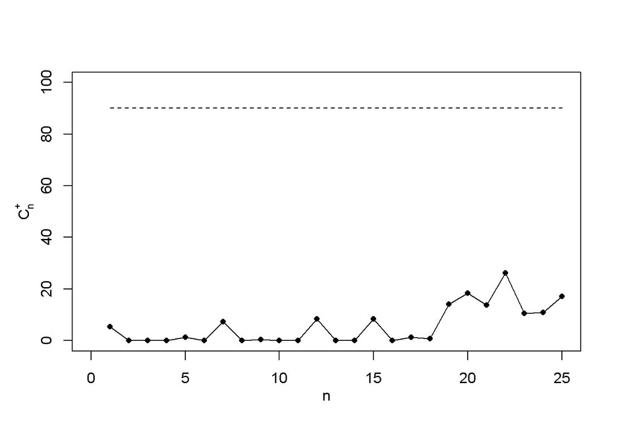

```r
#1/ARL=1/ARL(+)+1/ARL(-) where ARL(+)=ARL(-)
#h=10 gives arl0 500
h=10
K=k*sigma_hat
H=h*sigma_hat

cnx_p <- rep(0,length(x))
cnx_m <- rep(0,length(x))
cnx_p[1]<-max(0,0+(x[1]-mu0_hat-K))
cnx_m[1]<-max(0,mu0_hat-K-x[1])

for(i in 2:length(x)){
  cnx_p[i]<-max(0,cnx_p[i-1]+x[i]-mu0_hat-K)
  cnx_m[i]<-min(0,cnx_m[i-1]+mu0_hat-x[i]-K)
}

#Upper CUSUM Statistic CUSUM Chart
plot(t_vec,cnx_p,type="o",lty=1,pch=16,
     xlab="n",ylab=expression(C[n]^{"+"}),mgp=c(2,1,0),
     xlim=c(0,length(t_vec)),
     ylim=c(0,100),cex=0.8)
lines(t_vec,rep(H,length(t_vec)),lty=2,cex=0.8)
```

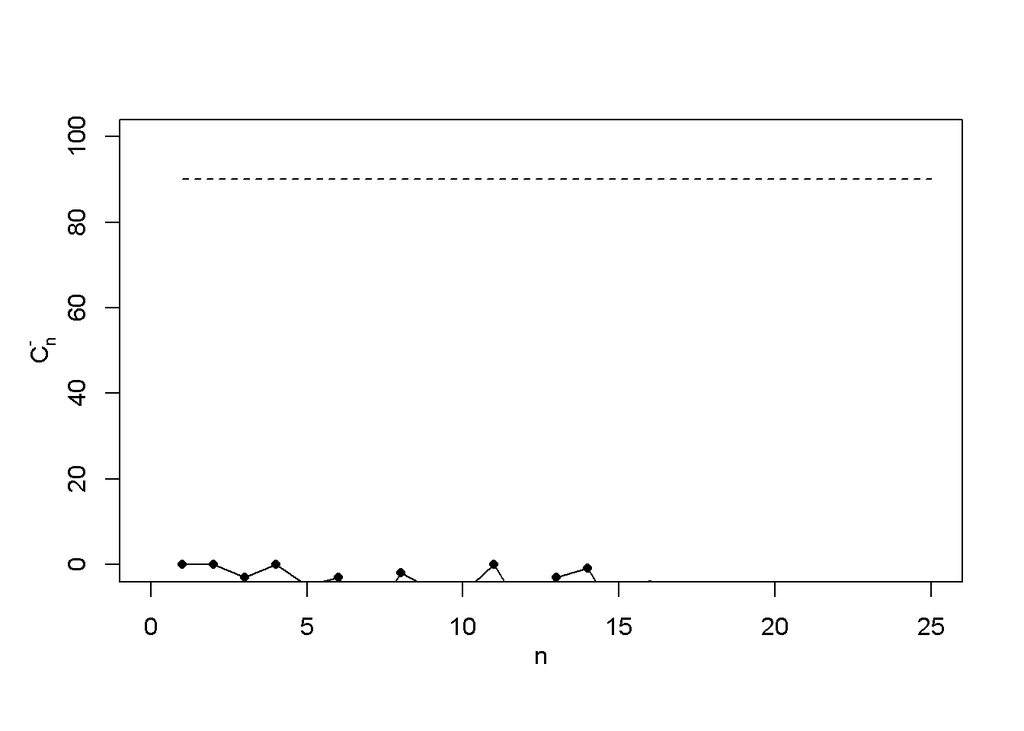

```r
#Lower CUSUM Statistic CUSUM Chart
plot(t_vec,cnx_m,type="o",lty=1,pch=16,
     xlab="n",ylab=expression(C[n]^{"-"}),mgp=c(2,1,0),
     xlim=c(0,length(t_vec)),
     ylim=c(0,100),cex=0.8)
lines(t_vec,rep(H,length(t_vec)),lty=2,cex=0.8)
```

k=0.2일 때, 앞선문제에서 설정한 값 ARL0=500을 주는 h 값을 Siegmund Approximation을 통해 구하였다(h=10). 위 설정 값들을 통해 reference value와 limit line을 두어 C+와 C- 특성치를 분석한 결과 특성치 모두 Limit 안에 들어와 공정이 I.C. 상태임을 알 수 있다.

# Q7

```r
arl0 <- function(h,k){
  return((exp(2*k*(h+1.166))-2*k*(h+1.166)-1)/(2*k^2))
}
arl1 <- function(h,k,delta,lambda,sigma){
  h_s <- h/(lambda*sigma)
  k_s <- (k-delta)/(lambda*sigma)
  if(k_s==0){
    return((h_s+1.166)^2)
  }
  else{
    return(arl0(h_s,k_s))
  }
}
#arl0(4.095,0.5) approximately 370
arl1(4.095,0.5,0.5,1,1) #N(0.5,1)
```

```
## [1] 27.67812
```

```r
arl1(4.095,0.5,1,1,1)   #N(1,1)
```

```
## [1] 8.53238
```

```r
arl1(4.095,0.5,-1,1,1)  #N(-1,1)
```

```
## [1] 1589484
```

```r
arl1(4.095,0.5,0,2,1)   #N(0,4)
```

```
## [1] 19.03863
```

```r
arl1(4.095,0.5,0,0.5,1) #N(0.0.25)
```

```
## [1] 66909577
```

```r
arl1(4.095,0.5,1,2,1)   #N(1,4)
```

```
## [1] 6.458306
```

# Q8

```r
library(spc)
xewma.arl(l=0.1,c=1,mu=1)
```

```
## [1] 3.218357
```

```r
xewma.arl(l=0.1,c=2,mu=1)
```

```
## [1] 6.504476
```

```r
xewma.arl(l=0.5,c=1,mu=1)
```

```
## [1] 2.058244
```

```r
xewma.arl(l=0.5,c=2,mu=1)
```

```
## [1] 4.804702
```

```r
xewma.arl(l=0.1,c=10,mu=5)
```

```
## [1] 6.372125
```

```r
xewma.arl(l=0.5,c=10,mu=5)
```

```
## [1] 19.65306
```

true mean=0으로 설정하고 문제를 풀어보았다. a)Compare 1&2, 3&4. lambda의 값이 같을 때, c 값이 증가할수록 ARL은 증가하였다. 이는 c, 즉 Limit line을 위로 올리면 chart가 처음으로 signal하기까지의 시간이 길어지기 때문이다. b)Compare 1&3, 5&6. 같은 C 값에서 lambda의 값이 증가할수록 ARL이 감소하였지만 이는 일반적인 사실이 아니다. 문제에서 요구하지는 않지만 c=10이고 true mean=5인 경우는 오히려 lambda의 값이 증가할 때 ARL이 증가하였다. 따라서 같은 c 값에서 lambda와 ARL은 일관성 있는 관계를 보여주지 않는다. 작은 lambda는 작은 shift를 잘 detect하며 큰 lambda는 큰 shift를 잘 detect하는데, 문제에서 제시하는 c=1은 작은 shift에 해당하고, 따라서 ARL0는 lambda가 작은 경우에서 더 크게 나타난다(ARL0는 클수록 좋고, ARL1은 작을 수록 좋음). 반대로 c=10은 큰 shift에 해당하므로 lambda가 클수록 ARL0가 크게 나타난다.

# Q9

```r
xewma.crit(l=0.1,L0=150,mu0=0)
```

```
##       c
## 2.23581
```

```r
xewma.crit(l=0.5,L0=150,mu0=0)
```

```
##        c
## 2.532631
```

```r
xewma.crit(l=0.1,L0=450,mu0=0)
```

```
##       c
## 2.69984
```

```r
xewma.crit(l=0.5,L0=450,mu0=0)
```

```
##        c
## 2.910679
```

```r
xewma.crit(l=0.1,L0=300,mu0=10)
```

```
##        c
## 45.46928
```

```r
xewma.crit(l=0.5,L0=300,mu0=10)
```

```
##        c
## 19.99025
```

true mean=0으로 설정하였다. a)Compare 1&2, 3&4, 5&6. 1&2, 3&4를 비교하였을 때 같은 ARLO 값에서 lambda 값이 증가할수록 crit도 증가하였다. 그러나 5&6을 비교하면 mu0가 큰 상황에서 같은 ARL0 값일 때 lambda가 증가할 때 crit은 감소하였다. 그 이유는 mu0가 큰 경우 mean shift도 커진다고 생각하면 큰 mean shift를 잘 detect하는 것은 lambda가 큰 경우고, 따라서 같은 ARL0 값을 유지하려면 crit 값은 감소해야 한다(crit이 작으면 ARL0도 작아짐 효과+큰 shifting에서 lambda가 크면 ARL0 커짐=>상쇄)

b)Compare 1&3, 2&4. 같은 lambda 값에서, ARL0 값이 증가할수록 crit도 증가하였다. 이는 앞선 문제 Q8에서 논의한 바와 같이, Chart상에서 Limit Line이 상승하면 Chart가 signal하기까지 걸리는 시간이 증가하므로 ARL0는 증가한다. 따라서 crit과 ARL0는 양의 상관관계를 가지게 된다.